# AROC (Archrock) 기업 분석 보고서

Alpha Hunter Hidden Gem Week 1 — 미국 천연가스 압축 인프라 독점

Author

Alpha Hunter × Chimera AI

Published

April 26, 2026

# 기업 개요

| 항목 | 내용 |
| --- | --- |
| **종목명** | Archrock Inc. (AROC, NYSE) |
| **업종** | Energy / 천연가스 압축 서비스 |
| **핵심 사업** | 천연가스 생산·수송용 압축 장비 임대 및 운영 |
| **시총** | $6.5B (약 9.1조원) |
| **현재가** | $37.33 |
| **PER (TTM/Fwd)** | 20.4x / 16.3x |
| **PBR** | 4.4x |
| **배당수익률** | 2.2% |
| **컨센서스** | Strong Buy (매수 8 / 중립 0 / 매도 0) |
| **목표가** | $38.0 ~ $42.0 (평균 $39.7) |

**핵심 투자 포인트**

미국 천연가스 압축 시장 1위. LNG 수출 16.7 Bcf/day 확대 직접 수혜. 가동률 85%+ 유지. 매출 +29% YoY 성장에도 영업이익 +57% 레버리지 효과. **애널리스트 8명 전원 Strong Buy.**

## 0.1 사업 요약

Archrock은 **미국 최대 천연가스 압축 서비스 기업**이다. 셰일가스 생산 현장에서 가스를 파이프라인으로 보내기 위한 압축 장비를 **임대·운영·유지보수**하는 비즈니스 모델.

- **미국 천연가스 압축 시장 점유율 1위** — 경쟁사 대비 압도적 장비 규모
- **LNG 수출 확대** 16.7 Bcf/day → 압축 수요 구조적 증가
- **장기 계약 기반** — 고객 전환비용 높음 (해자)
- **Q4 2025 EPS $0.69** — 컨센서스 대비 77% 상회
- **2026 EBITDA 가이던스** $890M — 시장 기대 초과

# 1 실적 분석

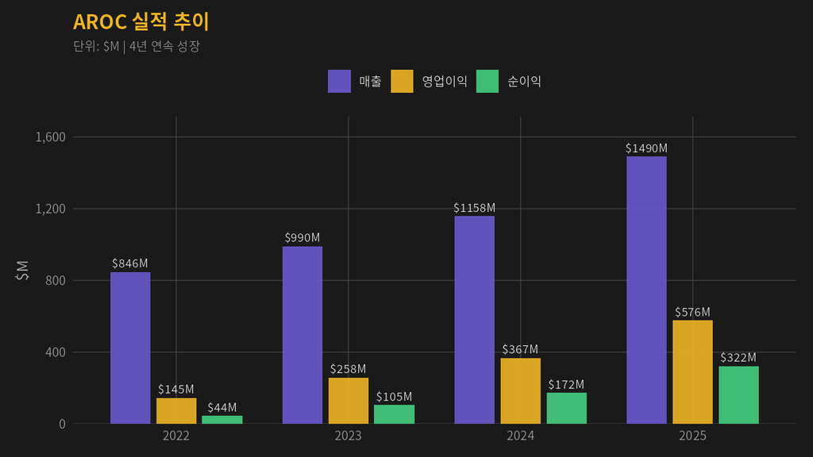

Figure 1: AROC 매출·영업이익·순이익 추이

## 1.1 핵심 재무 지표

| 지표 | 2022 | 2023 | 2024 | 2025 |
| --- | --- | --- | --- | --- |
| 매출 | $846M | $990M | $1,158M | **$1,490M** |
| 영업이익 | $145M | $258M | $367M | **$576M** |
| 영업이익률 | 17.1% | 26.1% | 31.7% | **38.7%** |
| 순이익 | $44M | $105M | $172M | **$322M** |
| EBITDA | - | - | - | **$833M** |
| 매출 성장 | - | +17% | +17% | **+29%** |

## 1.2 성장성 분석

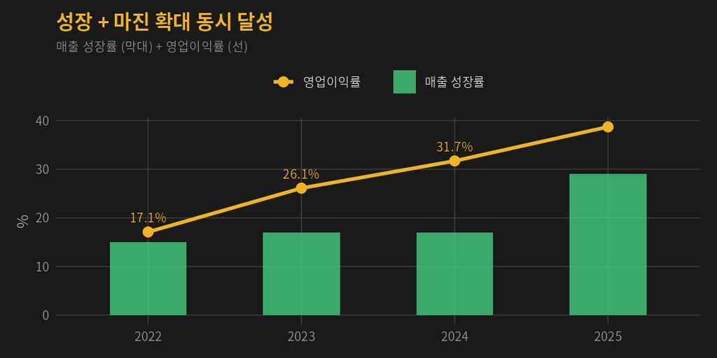

Figure 2: 매출 성장률 vs 영업이익률 추이

**인사이트**

매출이 29% 성장하는 동안 영업이익률은 17% → 39%로 **2배 이상 확대**. 고정비 레버리지가 극대화되는 구간. 장비 가동률 85%를 넘기면 추가 매출이 거의 순이익으로 전환.

# 2 리스크 분석

## 2.1 부채 구조

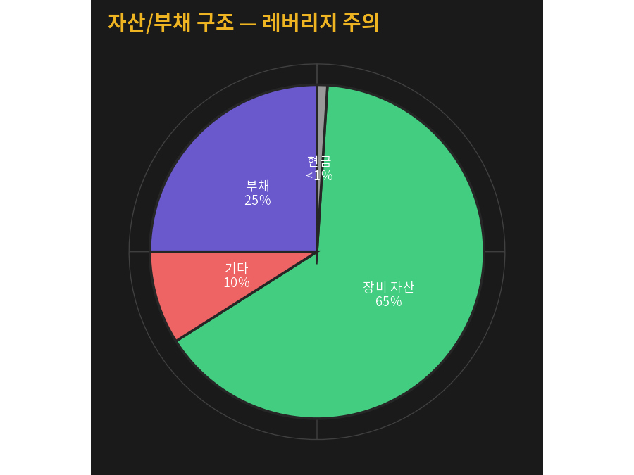

Figure 3: AROC 자산/부채 구조

## 2.2 주요 리스크

- **부채 $2.4B** — 레버리지 비율 2.7x (업종 평균 대비 높은 편)
- **천연가스 가격 하락** — 가스 가격 장기 하락 시 시추 활동 감소 → 압축 수요 감소
- **금리 민감** — 변동금리 부채 비중 → 금리 상승 시 이자비용 증가
- **에너지 전환 리스크** — 장기적으로 화석연료 수요 감소 가능성
- **FCF 대비 배당** — 배당 커버리지 모니터링 필요

# 3 투자자 렌즈 분석

## 3.1 워런 버핏 — “경제적 해자 + 가치”

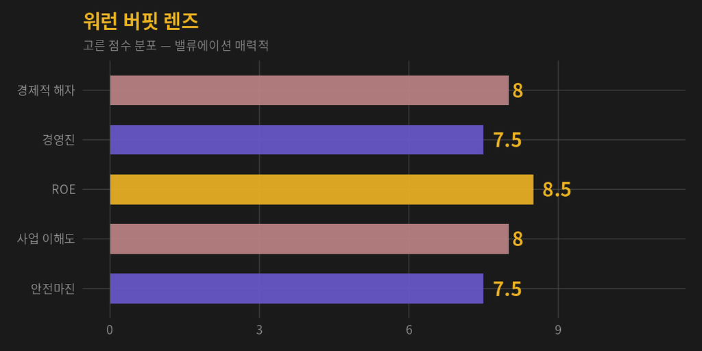

Figure 4: 워런 버핏 렌즈 평가

| 항목 | 점수 | 평가 |
| --- | --- | --- |
| 경제적 해자 | 8.0 | 시장 1위 + 고객 전환비용 높음 + 장기계약 |
| 경영진 | 7.5 | 가동률 85%+ 유지, 자본 배분 양호 |
| ROE | **8.5** | 순이익 급증 + Forward PE 16x로 매력적 |
| 사업 이해도 | 8.0 | 단순 명료한 BM (장비 임대) |
| 안전마진 | **7.5** | Forward PE 16x — HPSP(48x) 대비 훨씬 저평가 |

> 버핏 총평: “이해하기 쉽고, 해자가 있고, 저렴하다. 부채만 관리되면 장기 보유 적합.”

## 3.2 아이칸 렌즈 — “행동주의 관점”

| 항목 | 평가 |
| --- | --- |
| 자산 재배치 | 압축기 자산 가치 높음 → 분사/매각 가치 존재 |
| 배당 정책 | 2.2% 배당 + 자사주 매입 → 주주 환원 양호 |
| 경영 효율 | 영업이익률 39% → 이미 효율적 운영 |
| 행동주의 매력 | 낮음 — 이미 잘 경영되고 있음 |

## 3.3 피터 린치 — “10배 주식 가능성”

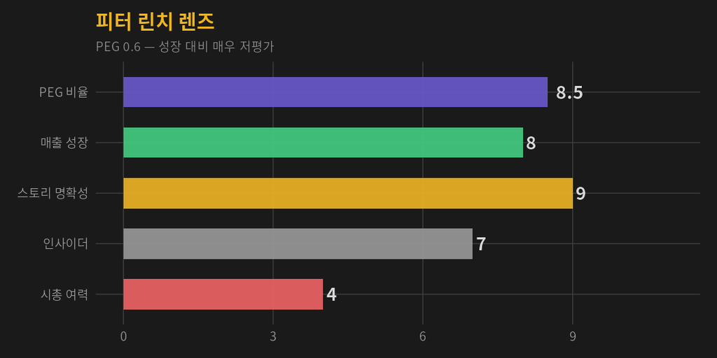

Figure 5: 피터 린치 렌즈 — 10배 주식 점검

| 항목 | 수치 | 평가 |
| --- | --- | --- |
| PEG 비율 | **~0.6** | 매우 매력적 (1 미만) |
| 매출 성장 | +29% YoY | 강력한 성장세 |
| 스토리 | 명확 | “LNG 수출 → 압축 수요 폭증” |
| 10배 가능성 | 낮음 | 시총 $6.5B → $65B은 어려움. **2배($75) 가능** |

# 4 종합 판정

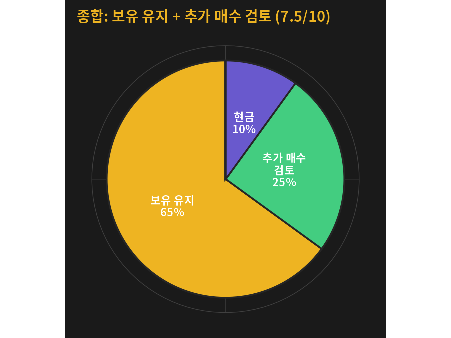

Figure 6: 투자 비중 배분

## 4.1 최종 판정: 보유 유지 + 추가 매수 검토

| 항목 | 가격 | 비고 |
| --- | --- | --- |
| 매수가 | $35.70 | 현재 $37.33 (**+4.56%**) |
| 추가 매수 | $34.00 이하 | 조정 시 분할 매수 |
| 목표가 | $42.00 | 애널리스트 상단 |
| 손절가 | $30.00 | -16% 하방 |

**액션 플랜**

1. **보유 유지** — 실적 모멘텀 강력, LNG 수출 확대 구조적 수혜
2. $34 이하 조정 시 **추가 매수** 검토
3. **부채 레버리지** 모니터링 — 금리 환경 변화 주시
4. 목표가 $42 도달 시 **20% 부분 매도**
5. 배당(2.2%) 재투자 전략 유지

*이 보고서는 가상 투자 시뮬레이션 목적으로 작성되었습니다. 실제 투자 권유가 아닙니다.*

*Alpha Hunter × Chimera AI | Vibe Investing Framework*